# Comparing species composition survey methods. Part 2a: Species Lists and Abundance Curves

Kelly Carscadden

2020-03-04

### 2. Community composition

#### Species Lists and Abundance Curves

Total species from *all hits*: 93

Total species from *top hits*: 83

Which species were totally missed by the top hits survey approach?

```
##  [1] "STEUMB"  "UNKTOL"  "ANTROS"  "CARSCO"  "CASOCC"  "CERBER"  "GENAMA"
##  [8] "MERLAN"  "NOCFEN"  "UNKGRA1"
```

How do abundance curves compare across the two survey methods (across sites, treatments)?

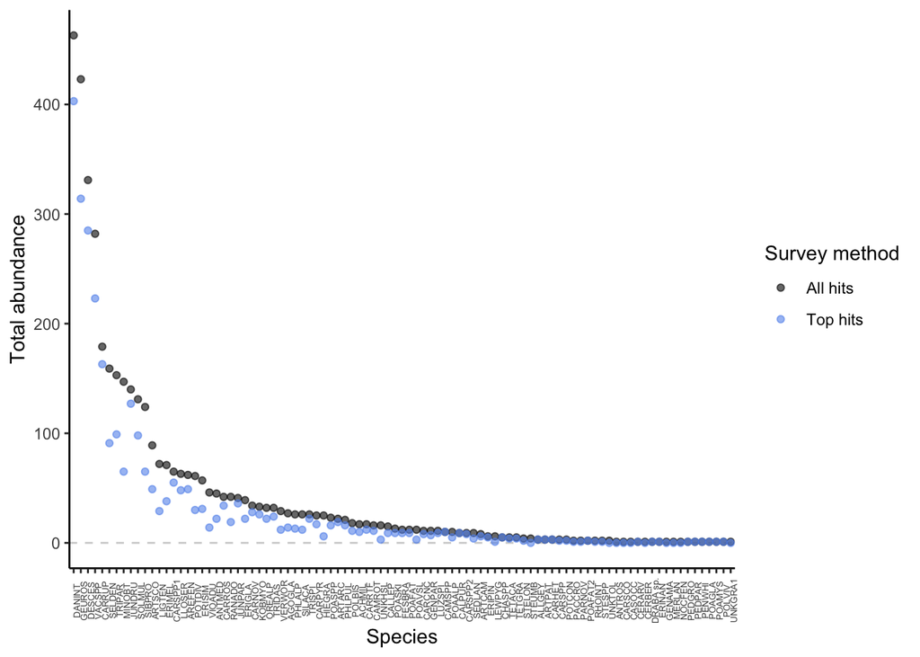

Across methods, abundances seem quite consistent. This plot suggests the main impact of top hits is:

1. decreasing the frequency of records of the most abundant species, and
2. losing a few of the rarest species

Does a top hit approach miss a consistent proportion of each species’ occurrences, or disproportionately miss certain species?

Formula: (tally_all_hits - tally_top_hits) / tally_all_hits

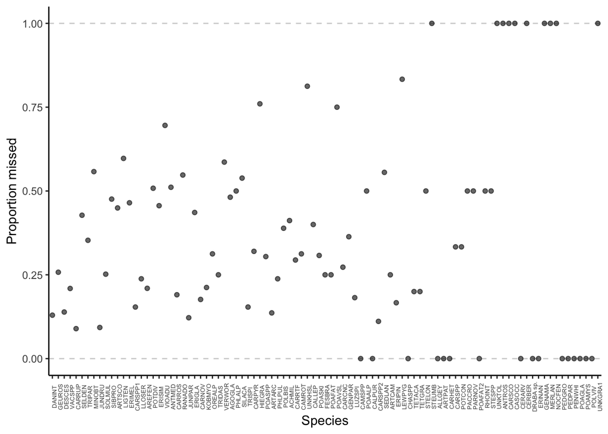

Species are displayed in order of decreasing abundance, as in the previous plot. As expected, rarer species vary in how they’re impacted (e.g., since one missed observation can mean 100% loss of that species, or conversely one top hit of a taller rare sp can be all that was seen, and lower canopy surveys would not have added more observations anyways).

Proportion loss varies across species (i.e., is not that you consistently lose x% of all observations across the board, by using the top hits approach). So, the effects of top hits could be challenging to account for post-hoc.